# DSC513 Introduction to Data Science

| Started on | Saturday, 29 October 2022, 1:59 PM |
| --- | --- |
| State | Finished |
| Completed on | Saturday, 29 October 2022, 2:09 PM |
| Time taken | 9 mins 51 secs |

### Question 1

Complete

Marked out of 1.00

[figure not shown]

Flag question

#### Question text

The _____ package within tidyverse is used for transformation of data and includes functions that filter, arrange, rename, and transform.

a.

ggplot2

b.

dplyr

c.

stringr

d.

readr

### Question 2

Complete

Marked out of 1.00

[figure not shown]

Flag question

#### Question text

A type of variable in R that takes on a limited number of different values, i.e., a categorical variable.

a.

Factor

b.

Forcats

c.

Level

d.

Character

### Question 3

Complete

Marked out of 1.00

[figure not shown]

Flag question

#### Question text

What function is used to test the missing observation in data frame

a.

na()

b.

is.na()

c.

missing()

d.

NA.miss()

### Question 4

Complete

Marked out of 1.00

[figure not shown]

Flag question

#### Question text

Check the map given below: For creating this kind of markings in a map, we can use .........

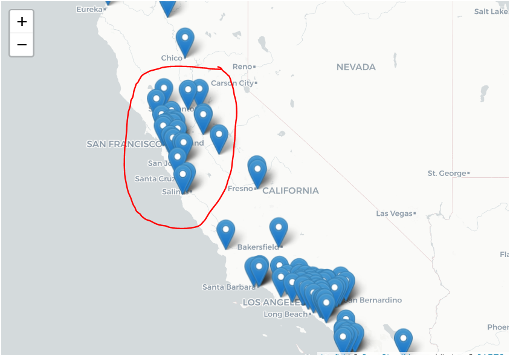

a.

All the listed choices here

b.

addpopups

c.

addMarkers

d.

addcircle

### Question 5

Complete

Marked out of 1.00

[figure not shown]

Flag question

#### Question text

............................ is a colour pallette provider plotting library which are designed in such a way that they will analytically be perfectly perceptually-uniform, both in regular form and also when converted to black-and-white.

a.

plot

b.

geom_hist()

c.

ggplot2

d.

Viridis

### Question 6

Complete

Marked out of 1.00

[figure not shown]

Flag question

#### Question text

Check the following statements and then select the below choices

i. In Setview function, dragging is TRUE by default

ii. In addcircleMarkers we can decide the size of the radius

a.

Both i and ii are TRUE

b.

Both i and ii are FALSE

c.

Only i is TRUE

d.

Only ii is TRUE

### Question 7

Complete

Marked out of 1.00

[figure not shown]

Flag question

#### Question text

The _____ package is used to create much more in-depth graphics and graphical representations.

a.

gplots

b.

plots3

c.

ggplot2

d.

grapher

### Question 8

Complete

Marked out of 1.00

[figure not shown]

Flag question

#### Question text

Imagine that you have been given a dataset which has most of the variables as Qualitative variables, How do you combine together least/most common levels into a single level?

a.

fct_lump

b.

fct_collapse

c.

fct_shuffle

d.

fct_other

### Question 9

Complete

Marked out of 1.00

[figure not shown]

Flag question

#### Question text

Which is the default map tile in leaflet package?

a.

CartoDB

b.

OpenStreetMap

c.

OpenWeatherMap.Precipitation

d.

Esri.WorldGrayCanvas

### Question 10

Complete

Marked out of 1.00

[figure not shown]

Flag question

#### Question text

What is the problem with the dataset shown below?

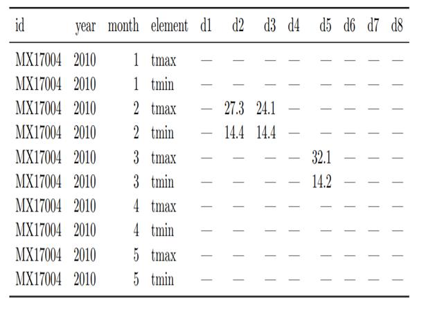

a.

Multiple variables stored in one column

b.

Variables are stored in both rows and columns

c.

Column headers are values, not variable names

d.

Multiple types in one table